# Einstieg in Matplotlib

Matplotlib ist eine weit verbreitete Bibliothek in Python zur Erstellung von statischen, animierten und interaktiven Visualisierungen.

Sie wird mit dem folgenden Befehl importiert:

```python
import matplotlib.pyplot as plt
```

Mit `plt.plot(x, y)` kann man ein Diagramm zu einer Wertetabelle erstellen. Dazu muss `x` die x-Werte und `y` die y-Werte jeweils in Form einer Liste enthalten.

Beispiel: Zu folgender Wertetabelle soll ein Diagramm erstellt werden:

| x | y |
| --- | --- |
| 1 | 2 |
| 2 | 3 |
| 3 | 5 |
| 4 | 7 |

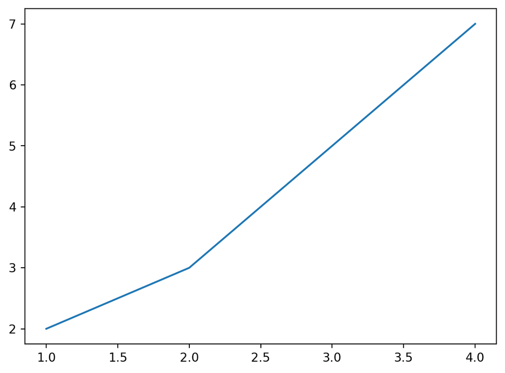

```python
import matplotlib.pyplot as plt
x = [1, 2, 3, 4]
y = [2, 3, 5, 7]
plt.plot(x, y)
plt.show()
```

Die Anweisung `plt.show()` sorgt dafür, dass das Diagramm angezeigt wird. Zwischen `plt.plot(...)` und `plt.show()` können weitere Anpassungen am Diagramm vorgenommen werden, z.B. Achsenbeschriftungen oder Einstellungen zur Skalierung.

In der Grundeinstellung werden die einzelnen Punkte mit Strecken verbunden. Will man nur einzelne Punkte, so kann man dies durch ein zusätzliches Argument `'o'` beim Aufruf von `plt.plot(...)` erreichen:

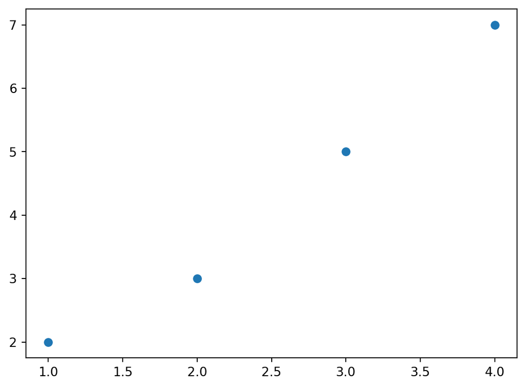

```python
plt.plot(x, y, 'o')
plt.show()
```

In der [Matplotlib-Dokumentation](https://matplotlib.org/stable/api/_as_gen/matplotlib.pyplot.plot.html) sind weitere Möglichkeiten zur Gestaltung der Linien und Punkte beschrieben (runterscrollen bis zum Abschnitt “Format Strings”).

Weitere Anpassungsmöglichkeiten:

- Die Achsen können mit `plt.xlabel("x-Achse")` und `plt.ylabel("y-Achse")` beschriftet werden.
- Mit `plt.title("Diagrammtitel")` kann ein Titel für das Diagramm gesetzt werden.
- Mit `plt.xlim(min, max)` und `plt.ylim(min, max)` können die Grenzen der x- und y-Achsen festgelegt werden.
- Mit `plt.grid()` kann ein Raster im Hintergrund des Diagramms angezeigt werden.

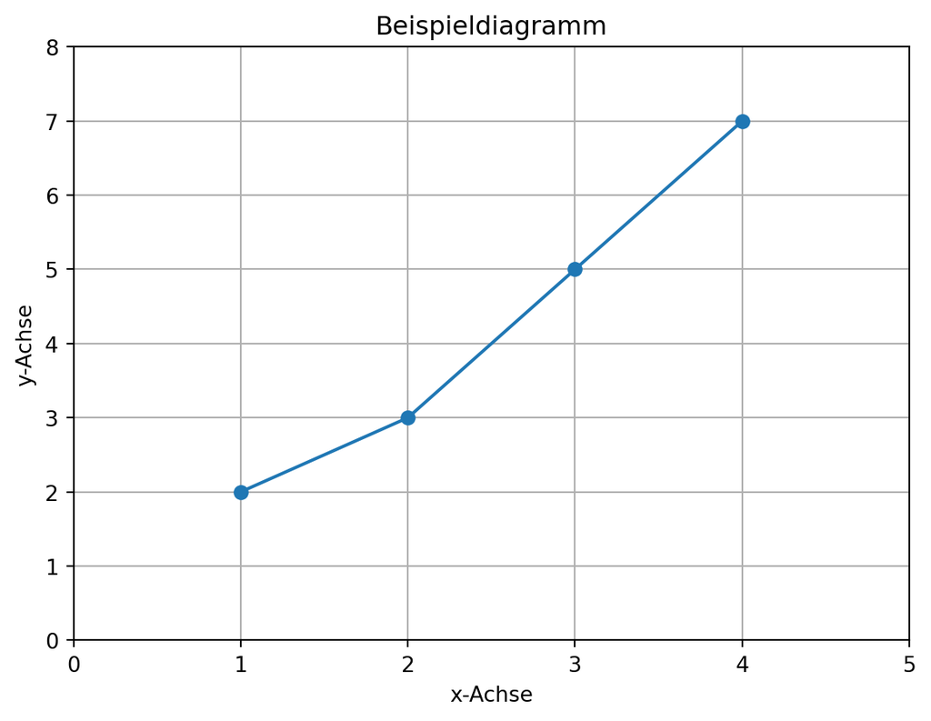

```python
plt.plot(x, y, 'o-')
plt.xlabel("x-Achse")
plt.ylabel("y-Achse")
plt.title("Beispieldiagramm")
plt.xlim(0, 5)
plt.ylim(0, 8)
plt.grid()
plt.show()
```